# Analisi Mega Analisi Ultra Analisi per l’ALTISSIMO

Accpet UnceRtainty

Authors

Affiliations

Simone Savoiani

DPSS - Dipartimento di Psicologia dello Sviluppo e della Socializazzione

Tito Maria Morlini

DPG - Dipartimento di Psicologia Generale

Published

April 2, 2025

## 1 Abstract

In questa ricerca è stato raccolto un grande campione, a cui è poi stato somministrato il Test sull’Autostima ideato da Rosenberg (Rosenberg, 1965).

Io ed il mio collega ci siamo sentiti dei fighi assurdi, ma non troppo, perchè il nostro credo è: “**BE MODEST**”

## 2 Analisi Descrittiva

Allora, il campione, preso tra ragazzi dai 18 ai 25 anni, è composto da 7735 persone, di cui di seguito le percentuali di maschi e femmine: 35, 65.

Di seguito ci sarà un grafico a barre delle età dei partecipanti, che si può ottenere con il codice:

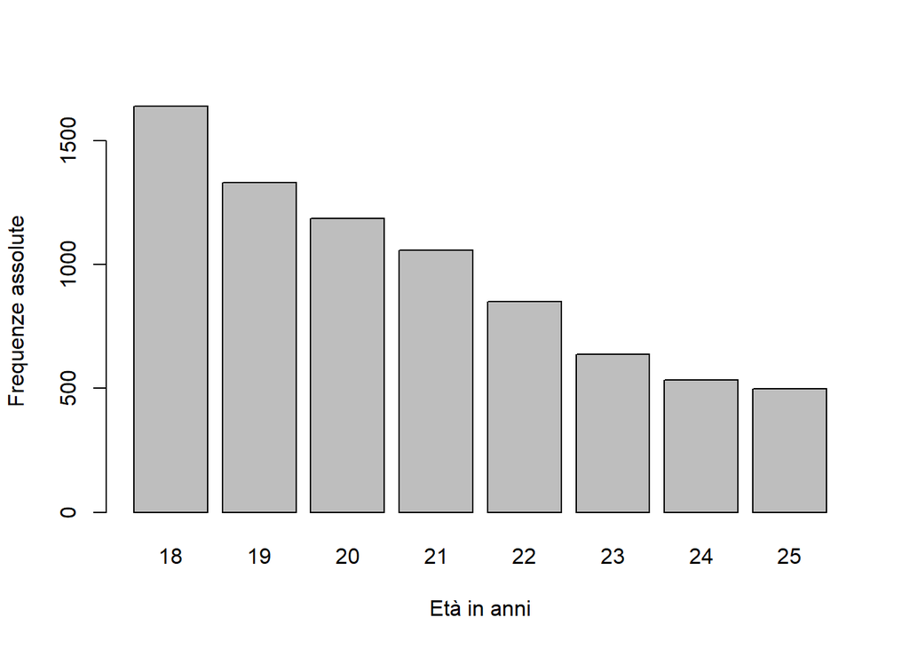

```r
 barplot(table(DATA$age), xlab="Età in anni",ylab="Frequenze assolute")
```

É bello? Lo so, ma che ci vuoi fare, quando hai dei dati così belli. Infatti l’età del campion ha media: 20.61 e deviazione standard: 2.17.

## 3 Analisi dei dati

Analizzando i dati sull’autostima, possiamo ottenere, con i seguenti codici, dei bellissimi grafici:

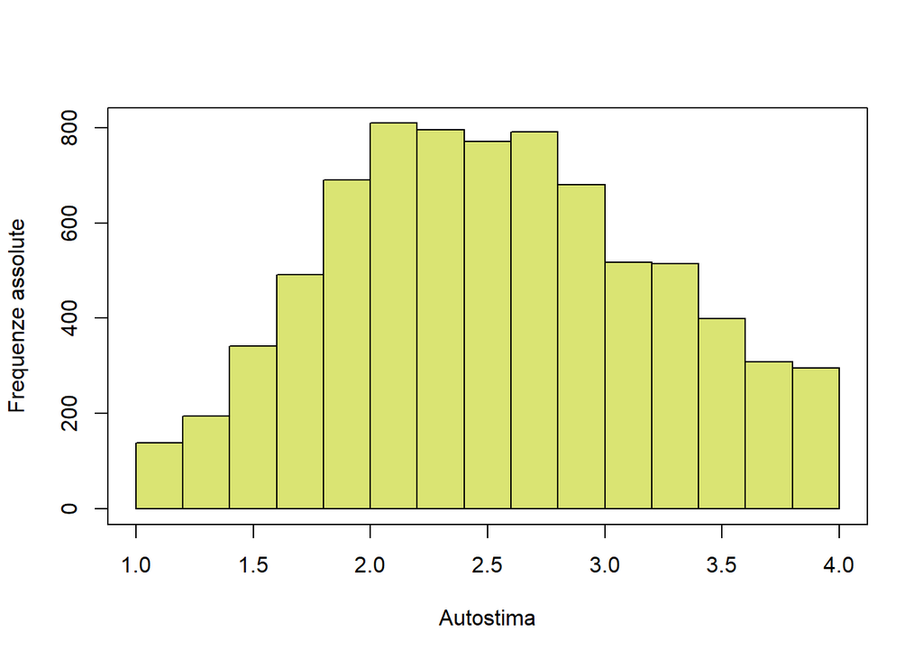

```r
par(mfrow=c(1,1))
hist(DATA$autostima,col= "#dae473" ,main=" ", ylab="Frequenze assolute", xlab = "Autostima")
box()
```

Si nota chiaramenti che l’autostina ha media: 2.58, e deviazione standard: 0.69.

Un’altro grafico potrebbe essere, invece:

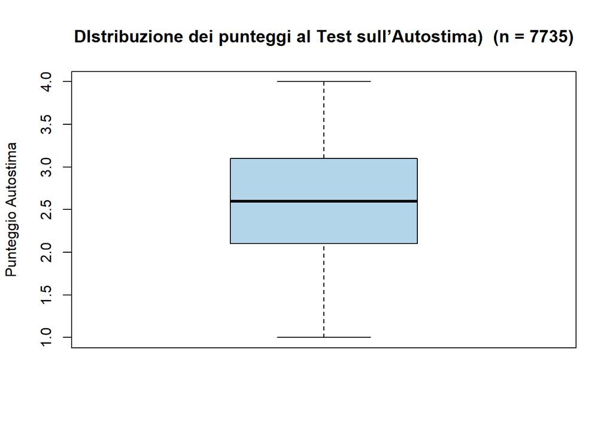

```r
boxplot(DATA$autostima, ylab="Punteggio Autostima", col="#b3d5e9", main="DIstribuzione dei punteggi al Test sull’Autostima)  (n = 7735)")
```

## 4 Questioni di genere

Analizzando i dati in base al genere, si può notare questa cosa:

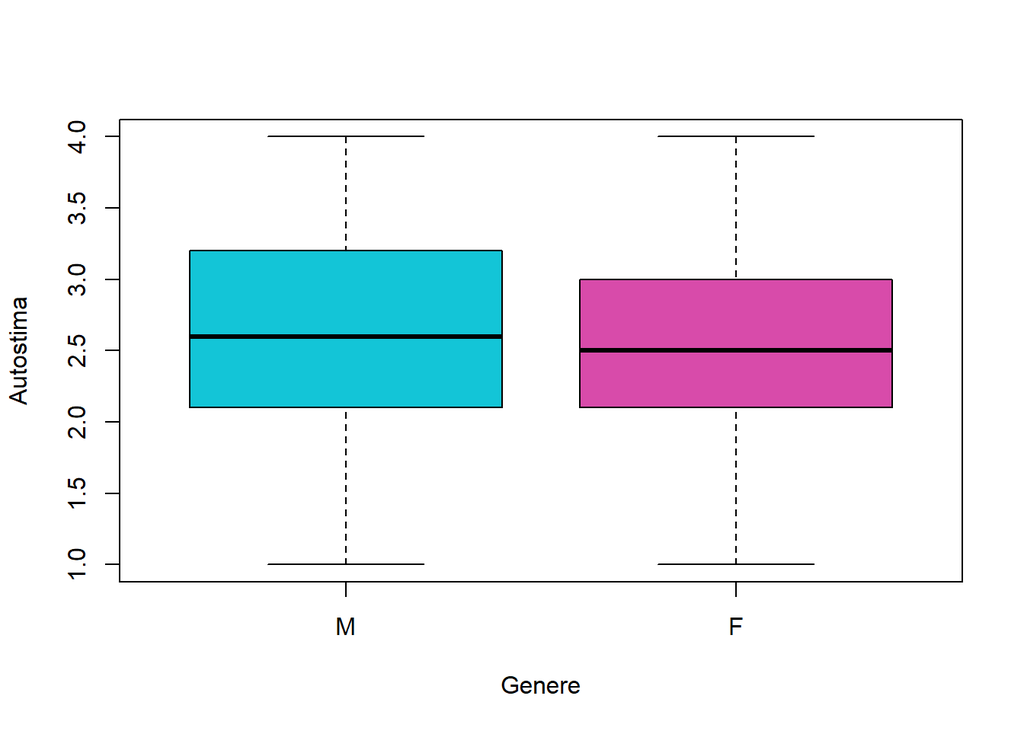

```r
boxplot(autostima ~ gender,data=DATA, col=c("#13c5d7","#d84baa"), ylab="Autostima",xlab="Genere")
```

### 4.1 Boh tanta roba

I motivi possono essere veramente tanti, ma i più probabili potrebbero essere:

**Maschi (M):**

- sono BELLI
- sono INTELLIGENTI
- sono DETERMINATI

**Femmine (F):**

- sono BELLE
- sono INTELLIGENTI
- sono DETERMINATE

**Maschi**

- sono BELLI
- sono INTELLIGENTI
- sono DETERMINATI

**Femmine**

- sono BELLE
- sono INTELLIGENTI
- sono DETERMINATE

## 5 Conclusioni

Non lo so, non ho letto bene le abalisi che io stesso ho fatto. Guardando i grafici (che belli i box plot, grazie Tukey di essere nato), direi che la media dell’autostima dei maschi è un po più alta rispetto a quelle delle femmine, ma anche la sd dei maschi è più alta.

Ricordate, l’importante è essere dei chill guy. Curiosity killed the cat, ma almeno si è divertito.

[figure not shown]

## References

Rosenberg, M. (1965). Rosenberg self-esteem scale (RSE). *Acceptance and Commitment Therapy. Measures Package*, *61*(52), 18.